# Plotting

### B - Building a plot step-by-step

In this section, you’ll build the following plot step by step

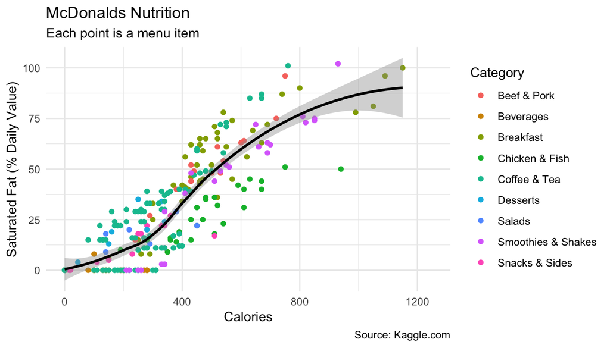

1. Using `ggplot()`, create the following blank plot using the `data` and `mapping` arguments (but no geom). Use `calories` for the x aesthetic and `saturated_fat` for the y aesthetic

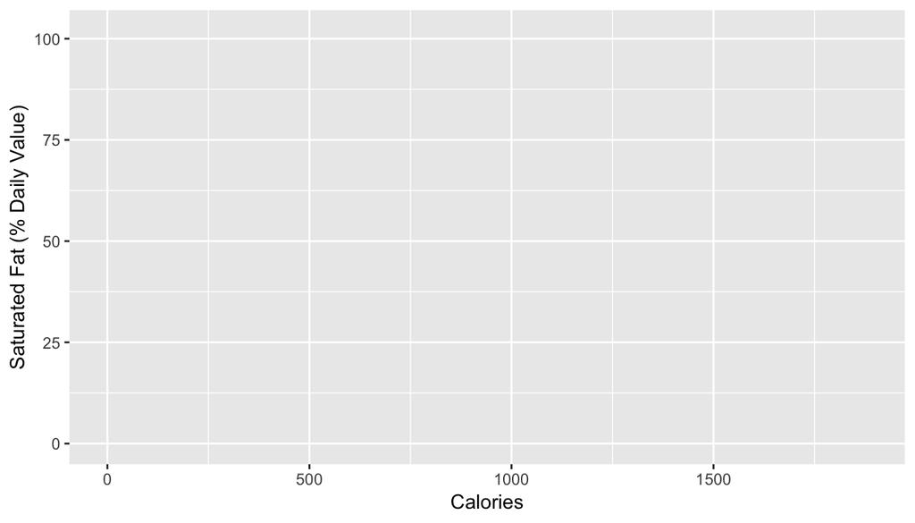

```r
ggplot(data = mcdonalds,
       mapping = aes(x = XX, y = XX))
```

2. Using `geom_point()`, add points to the plot

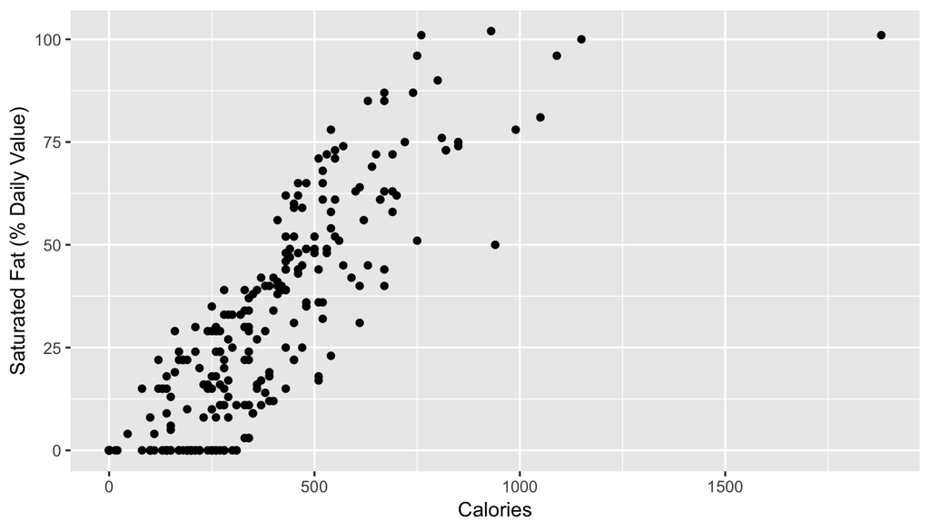

```r
ggplot(data = mcdonalds,
       mapping = aes(x = XX, y = XX)) +
  geom_point()
```

32. Using the `color` aesthetic mapping, color the points by their Category.

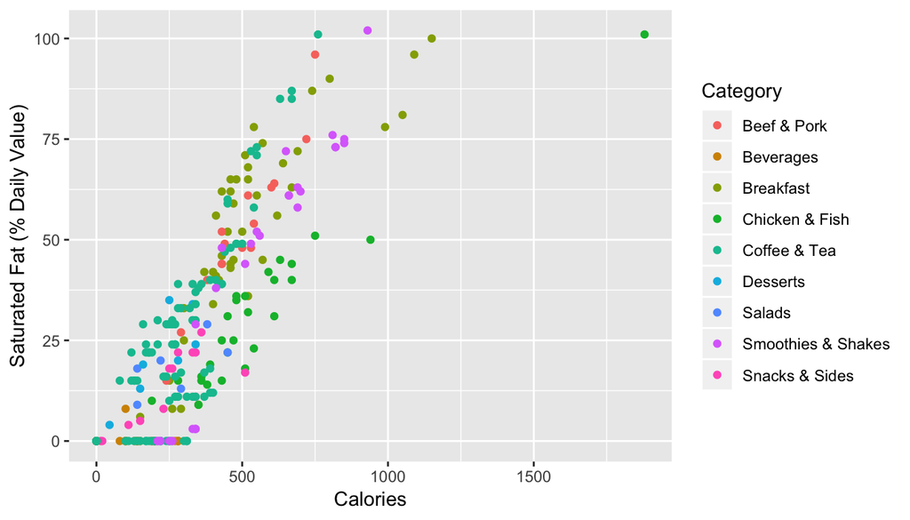

```r
ggplot(mcdonalds, aes(x = XX, y = XX, col = XX)) +
  geom_point()
```

4. Add a smoothed average line using `geom_smooth()`.

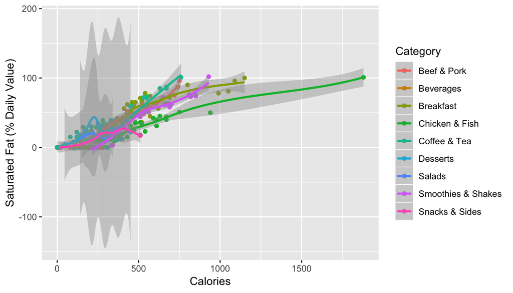

```r
ggplot(mcdonalds, aes(x = XX, y = XX, col = XX)) +
  geom_point() +
  geom_smooth()
```

5. Oops! Did you get several smoothed lines instead of just one? Let’s fix it by specifying that the line should have one color: “black”. When you do, you should then only see one line.

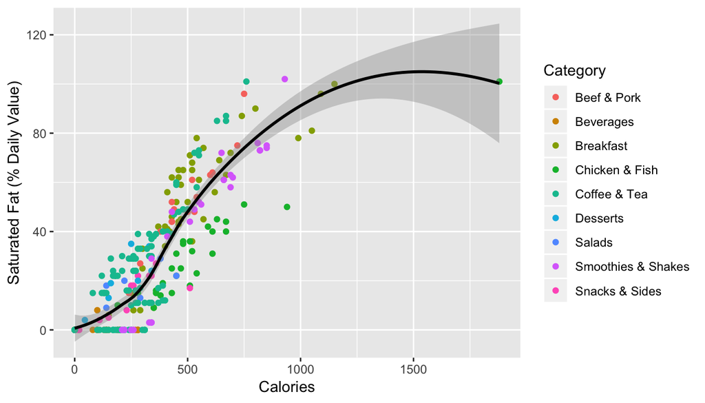

```r
ggplot(mcdonalds, aes(x = XX, y = XX, col = XX)) +
  geom_point() +
  geom_smooth(col = "XX")
```

6. Add appropriate labels using the `labs()` function

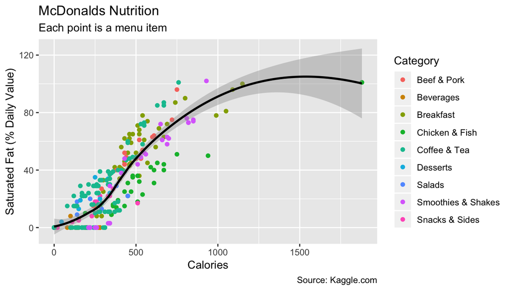

```r
ggplot(mcdonalds, aes(x = XX, y = XX, col = XX)) +
  geom_point() +
  geom_smooth(col = "XX") +
  labs(title = "XX",
       subtitle = "XX",
       caption = "XX")
```

7. Set the limits of the x-axis to 0 and 1250 using `xlim()`

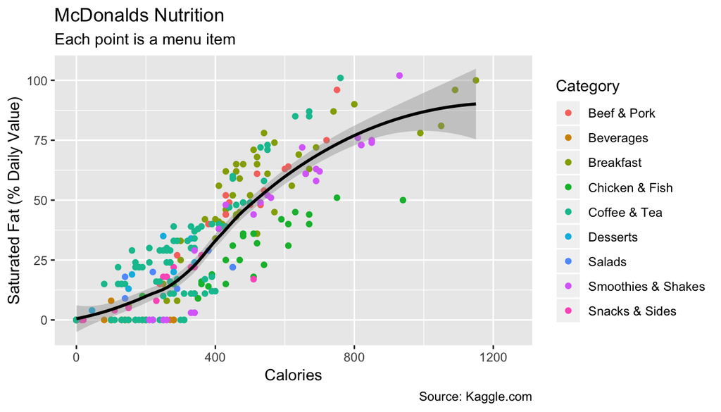

```r
ggplot(mcdonalds, aes(x = XX, y = XX, col = XX)) +
  geom_point() +
  geom_smooth(col = "XX") +
  labs(title = "XX",
       subtitle = "XX",
       caption = "XX") +
  xlim(XX, XX)
```

8. Finally, set the plotting theme to `theme_minimal()`. You should now have the final plot!

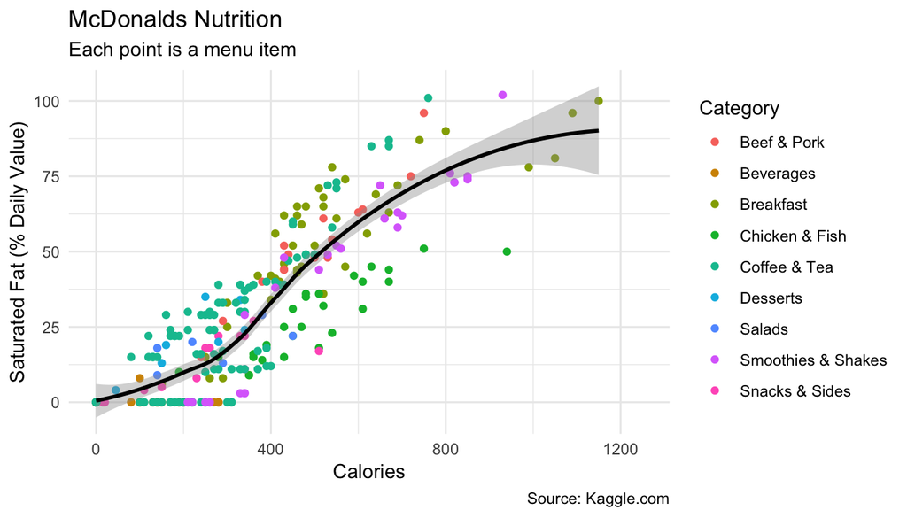

```r
ggplot(mcdonalds, aes(x = XX, y = XX, col = XX)) +
  geom_point() +
  geom_smooth(col = "XX") +
  labs(title = "XX",
       subtitle = "XX",
       caption = "XX")+
  xlim(XX, XX) +
  theme_minimal()
```

### C - Adding multiple geoms

1. Create the following plot showing the relationship between menu category and calories

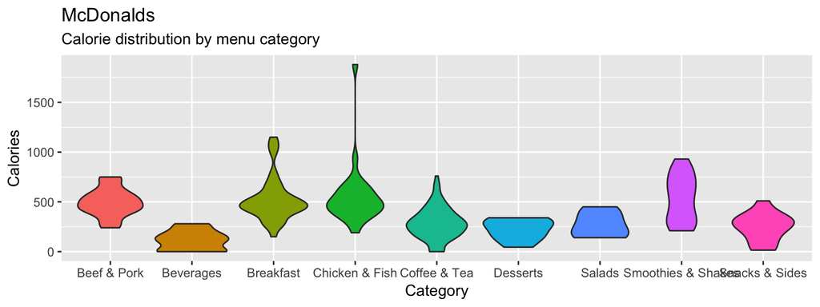

```r
ggplot(data = mcdonalds, aes(x = XX, y = XX, fill = XX)) +
  geom_violin() +
  guides(fill = FALSE) +
  labs(title = "XX",
       subtitle = "XX")
```

2. Include the additional argument `+ stat_summary(fun.y = "mean", geom = "point", col = "white", size = 4)` to include points showing the mean of each distribution

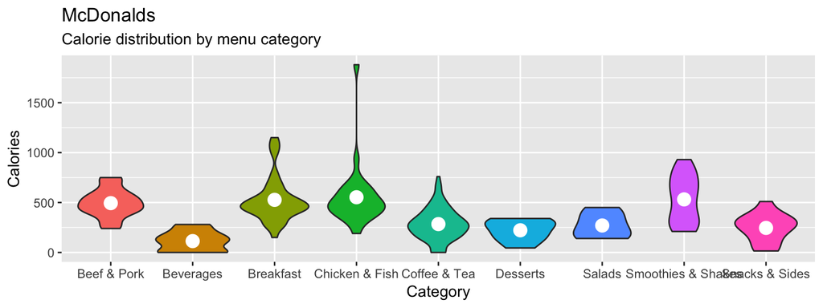

3. Now add `+ geom_jitter(width = .1, alpha = .5)` to your plot, what do you see?
4. Play around with your plotting arguments to see how the results change! Each time you make a change, run the plot again to see your new output!
- Change the summary function in `stat_summary()` from “mean” to “median”
- Change the size of the points in `stat_summary()` to something much bigger (or smaller).
- Change the `width` argument in `geom_jitter()` to `width = 0`
- Instead of using `geom_violin()`, try `geom_boxplot()`
- Remove the `fill = Category` aesthetic entirely.

### D - Using facets

```r
ggplot(XX, aes(x = XX, y = XX)) +
  geom_point(alpha = .2) +
  facet_wrap(~ XX) +
  labs(title = "XX",
       subtitle = "XX") +
  theme_minimal()
```

1. Create the following plot showing the relationship between Sodium and calories

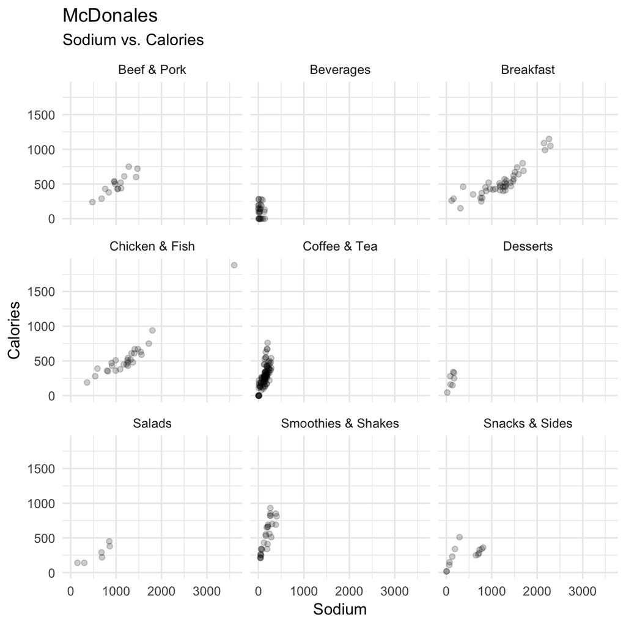

2. Try the following ways to customise your plot
- Color the points by `Category`
- Add a smoothed line to each plot with `geom_smooth()`

### E - Adjusting colors

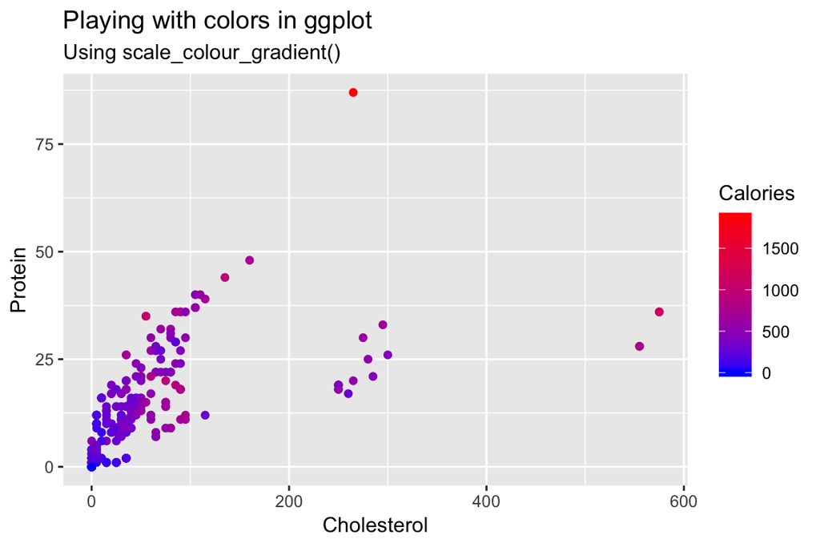

1. Create a scatterplot showing the relationship between Cholesterol and Protein
2. Color the points according to their Calories by specifying the `col` aesthetic
3. Change the colors by including the additional argument `+ scale_colour_gradient(low = "blue", high = "red")`
4. Use a gray color palette by using `scale_color_grey()` instead of `scale_colour_gradient()`
5. Customize!
- Look at all of the named colors in R by running `colors()`. Then, use two new colors in your plot.

### F - Adding labels

Let’s create the following plot with additional point labels using `geom_text():

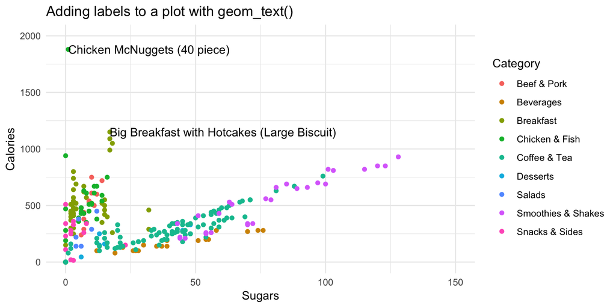

1. Start with the following template

```r
ggplot(mcdonalds, aes(x = XX,
                      y = XX,
                      col = XX)) +
  geom_point() +
  xlim(XX, XX) +
  ylim(XX, XX) +
  theme_minimal() +
  labs(title = "XX")
```

2. Try adding labels to the plot indicating which item each point represents by adding `+ geom_text()`.
3. Where are the labels? Ah we didn’t tell ggplot which column in the data represents the item descriptions. Fix this by specifying the `label` aesthetic in your first call to the `aes()` function. That is, include `label = Item` underneath `col = XX`. Now you should see lots of labels!
4. Customize your `geom_text()` by including the arguments: `geom_text(col = "black", check_overlap = TRUE, hjust = "left")`
5. Using the `data` argument in `geom_text()` specify that the labels should only apply to items over 1100 calories (hint: `geom_point(data = mcdonalds %>% filter(XX > XX))`)
6. Play around!
- Specify that the size of the points should correspond to their Calories. Do this with the `size` aesthetic.
- Instead of mapping Category to the color aesthetic, try creating different facets for each Category with `facet_wrap(~ Category)`
- Try using a different plotting theme. For example, you can try `theme_excel()` included in the `ggthemes` package.

### G - Summary statistics

1. Create the following plot showing the mean number of calories for each menu category using the following template

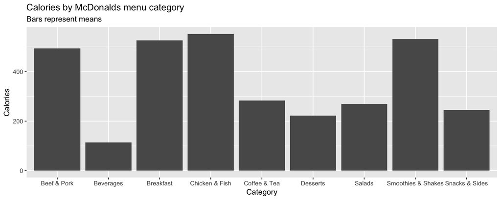

```r
ggplot(XX, aes(x = XX, y = X)) +
  stat_summary(geom = "bar",
               fun.y = "mean") +
  labs(title = "XX")
```

2. Customize your plot!
- Instead of showing the mean, show the median.
- Give each bar a different color.
- Add overlapping points showing the individual items using `geom_point()`, `geom_count()` or `geom_jitter()`

### H - Saving plots

1. It’s time to save your favorite plot to an image file! Pick your favorite plot you’ve created so far. Then, assign the plot to a new object called `mcdonalds_gg` using `mcdonalds_gg <- ggplot(...)`

```r
mcdonalds_gg <- ggplot(...) # Include your plotting code here
```

2. Evaluate your `mcdonalds_gg` object to see that it does indeed contain your plot.
3. Save your plot to a pdf file called `mcdonalds.pdf` using `ggsave()`. When you finish, open your plot to see how it looks!

```r
# Save mcdonalds_gg to a pdf file
ggsave(filename = "mcdonalds",
       device = "pdf",
       plot = mcdonalds_gg,
       width = 4,
       height = 4,
       units = "in")
```

4. Play around with the `width` and `height` arguments to change the dimensions of the plot.
5. Customize your code to create a jpeg image called `mcdonalds.jpeg`

### References and Further Reading

- The main `ggplot2` webpage at http://ggplot2.tidyverse.org/ has great tutorials and examples.
- Check out Selva Prabhakaran’s website for a nice gallery of ggplot2 graphics http://r-statistics.co/Top50-Ggplot2-Visualizations-MasterList-R-Code.html
- `ggplot2` is also great for making maps. For examples, check out Eric Anderson’s page at http://eriqande.github.io/rep-res-web/lectures/making-maps-with-R.html